# *Pteridium* GBS Pipeline

## Variants Calling

To call variants, we used the GATK HaplotypeCaller (v. 3.8.0) because of its ability to specify ploidy. We called variants separately for the diploids and tetraploids.

#### Diploids

```bash
java -Xmx48g -jar GenomeAnaysisTK.jar -T HaplotypeCaller -R ae_consensus_final -I diploid_bams.list --genotyping_mode DISCOVERY -ploidy 2 -o 2ae_rawVar.vcf -out_mode EMIT_VARIANTS_ONLY
```

#### Tetraploids

```bash
java -Xmx48g -jar GenomeAnaysisTK.jar -T HaplotypeCaller -R ae_consensus_final -I tetraploid_bams.list --genotyping_mode DISCOVERY -ploidy 4 -o 4ae_rawVar.g.vcf -out_mode EMIT_VARIANTS_ONLY --variant_index_type LINEAR --variant_index_parameter 128000
```

```bash
grep -v ^# ae.vcf | cut -f 8 | perl -p -i -e 's/DP=(\d+);\S+/\1/' > depth.txt
```

### Step 1: filter VCFs

VCFTOOLS (v. 0.1.15) can be used to filter diploids (see below), but because it does not support tetraploids we created a custom Python script to filter instead.

```bash
vcftools --remove-filtered-all --remove-indels --maf 0.1 --max-maf 0.99 --min-meanDP 2.0 --max-missing 0.3 --minQ 20 --recode-INFO-all --recode --vcf 2ae\_rawVar.vcf
```

BOTH VCF files need to be filtered this way (2ae_rawVar.vcf and 4ae_rawVar.vcf).

### Step 2: Find the intersection of variants in diploids and tetraploids

Since we now have two VCF files, we need to combine them again somehow. To do this, we find the **intersection** of the variants in both files, subset, and then re-combine.

#### a. Intersection of variants

```bash
perl vcf_checker.pl filtered_ae2.vcf filtered_4ae.vcf
```

Output is a list of the contigs present in both VCF files called matches.txt

#### b. Subset VCF files with list of intersection matches

Do this for both files.

```bash
perl subsetVcf.pl matches.vcf filtered_ae2.vcf

perl subsetVcf.pl matches.vcf filtered_ae4.vcf
```

Output is two files: sub_filtered_ae2.vcf and sub_filtered_ae4.vcf

#### c. Combine files

What we are doing here is appending the data from one file onto the end of each matching contig in the other file.

```bash
perl combine.pl sub\_filtered\_ae2.vcf sub\_filtered\_4ae.vcf
```

This outputs a file called aeAll.vcf

Our original sample size was 101 plus 15 replicates. Three of the samples were an outgroup, which we decided not to use in the admixture analysis. A fourth sample did not qork in sequencing; its initial FASTQ file was empty. After calling variants, we checked our replicates against their associated indiviual, and determined that all replicates had amplified properly and made it through the pipeline to match their original ID. We then combinded replicates to their associated individual and re-did the variant calling.

## Estimation of Admixture

### **Entropy**

Before getting started with Entropy, we need to convert our VCF file to a GL (Genotype Likelihood) file.

We used the perl script vcf2gl.pl to convert our filtered vcf to the simpler .gl format for downstream analysis.

For diploids:

```bash
perl vcf2gl.pl aeAll.vcf
```

This outputs a file called out.recode.gl

Next we are going to convert the GL file to a matrix that we can use in R with DAPC.

```bash
perl gl2genest.pl out.recode.gl
```

This outputs a file called pntest_out.recode.gl

### Discriminant Analysis of Principle Components

Among the diploid species, *Pteridium aquilinum* and *P. esculentum*, and the tetraploid species, *P. semihaustatum* and *P. caudatum*, there are 15 sub-species. These distinctions are based mostly on morphology, and so testing the population structure among them will help distinguish the validity of these biological species and sub-species.

##### a. seed entropy with values from DAPC

Using the R package ADEGENET (v. 2.1.1), run a Discriminate Analysis of Principle Componets (DAPC function) to seed values in ENTROPY so we don’t get label swapping. We followed the DAPC vignette.

```r
library(adegenet)

# read in genotype matrix
d <- read.table("pntest_out.recode.vcf", header = F)

# transform data
dt <- t(d)

# convert to genind object
dg <- df2genind(dt, sep = " ", ploidy = 2)

grp <- find.clusters(dg, max.n.clust = 15)
# number of PCs retained: 60
# number of clusters: 2

head(grp$grp, 97)

# get likelihood assignments

dapc1 <- dapc(dg, grp$grp)
# PCs 60
# discriminant dunctions: 1

write.table(dapc1$posterior, "k_est.txt")
```

##### b. run ENTROPY

```bash
./entropy -b 2000 -t 4 -k 2 -i ae_in.gl -o out.hdf5 -m 1 -w 0 -q pop_ests.txt -s 20
```

Usage: entropy -i infile.txt [options] -i Infile with genetic data for the population -l Number of MCMC steps for the analysis [default = 10000] -b Discard the first n MCMC samples as a burn-in [default = 1000] -t Thin MCMC samples by recording every nth value [default = 1] -k Number of population clusters [default = 2] -e Probability of sequence error, set to ‘9’ for locus-specific error rates [default = 0] -Q Estimate intra- and interspecific ancestry and marginal q [0 or 1, default = 0] -o HDF5 format outfile with .hdf5 suffix [default = mcmcout.hdf5] -m Infile is in genotype likelihood format [default = 0] -w Output includes population allele frequencies [default = 1] -q File with expected starting values for admixture proportions -s Scalar for Dirichlet init. of q, inversly prop. to variance [default = 1] -p +/- proposal for ancestral allele frequency [default = 0.1] -f +/- proposal for Fst [default = 0.01] -y +/- proposal for gamma [default = 0.2] -a +/- proposal for alpha [default = 0.1] -r INT seed for random number generator [default = clock]

##### c. ESTPOST - pulling out meaningful things from entropy

```bash
/home/skinosian/hts_tools/estpost_h5_entropy -o out_d -p deviance -s 3 -w 1 entropy_ae_k2_2.hdf5
```

-o outfile  
-p name of parameter to summarize  
-s which summary to perform:  
0 = posterior estimates and credible intervals  
1 = histogram of posterior samples  
2 = convert to plain text  
3 = calculate DIC  
4 = MCMC diagnostic  
- w write parameter identification to file, boolean

### **Visualizing Admixture**

```r
# read in files from estpost
k2_1 <- read.csv("k2_1.txt", sep = ',', header = T)
k2_1 <- k2_1[,-1]
k2_2 <- read.csv("k2_2.txt", sep = ',', header = F)
k2_3 <- read.csv("k2_3.txt", sep = ',', header = F)
k3_1 <- read.csv("k3_1.txt", sep = ',', header = F)
k3_2 <- read.csv("k3_2.txt", sep = ',', header = F)
k3_3 <- read.csv("k3_3.txt", sep = ',', header = F)
k4_1 <- read.csv("k4_1.txt", sep = ',', header = F)
k5_1 <- read.csv("k5_2.txt", sep = ',', header = F)
names <- read.csv("final_inds.csv", header = F)

# this function averages 3 chains for a given k
avg_k <- function(kval, ninds = 97, chain1, chain2, chain3){
    df <- as.data.frame(matrix(nrow = kval*ninds,  ncol = 4))
    colnames(df)[1:4] <- c("chain1", "chain2", "chain3", "avg")
    df[,1] <- chain1[,1]
    df[,2] <- chain2[,1]
    df[,3] <- chain3[,1]
    df[,4] <- round(rowMeans(df[sapply(df, is.numeric)]), digits = 6)
    return(df)
}

avg2 <- avg_k(kval = 2, chain1 = k2_1, chain2 = k2_2, chain3 = k2_3)
avg3 <- avg_k(kval = 3, chain1 = k3_1, chain2 = k3_1, chain3= k3_3)
avg4 <- avg_k(kval = 4, chain1 = k4_1, chain2 = k4_1, chain3= k4_1)
avg5 <- avg_k(kval = 5, chain1 = k5_1, chain2 = k5_1, chain3= k5_1)

# add lower bounds of error
#ak5[,5] <- k5[,3]

# add upper bounds of error
#ak5[,6] <- k5[,4]

# column names
#colnames(ak5)[5:6] <- c("LB", "UB")

# makes a data frame with your averaged chains
make_df <- function(kfile, kval, ninds = 97, names){
    x <- 1
    df <- as.data.frame(matrix(nrow = ninds, ncol = kval+x))
    for (i in 1:(kval)){
        df[,i] <- kfile[x:(ninds*i),4]
        x <- x+ninds
    }
    df[,ncol(df)] <- names
    df <- df[order(df[,ncol(df)]),]
    return(df)
}

df2 <- make_df(kfile = avg2, kval = 2, names = names[,3])
df3 <- make_df(kfile = avg3, kval = 3, names = names[,3])
df4 <- make_df(kfile = avg4, kval = 4, names = names[,3])
df5 <- make_df(kfile = avg5, kval = 5, names = names[,3])
k5List <- list(df5[,1:5])

allkList <- list(df2[,1:2], df3[,1:3], df4[,1:4], df5[,1:5])

# original function to plot each chain for a given k
plot_q_per_chain <- function(kqlist, xlabel, ...){
    cols <- c('#A8FFFD', '#B862D3','#A39D9D','#FFFF00', '#ff5a5a', '#69C261', '#26CDCD', '#C1C6FF')
    par(mfrow= c(length(kqlist),1), mar=c(4,2,1,1) + 0.1, oma= c(5,0,0,0), mgp= c(0,1,0))
    chain <- seq(1, length(kqlist), 1)
    for(i in 1:length(kqlist)){
        barplot(t(kqlist[[i]]), beside= F, col= cols, las= 2, axisnames= T, cex.name= 1, cex.axis= 1.2, border= 1.5, space= c(0.05,0.05), yaxt= 'n', ylab= paste("k =", chain[i]+1, sep= ' '), cex.lab= 2, names.arg= xlabel)
        axis(2, at= c(0, 0.25, 0.5, 0.75, 1), cex.axis= 1, las= 2, pos= -0.2)
        #arrows(eb2[,1], eb2[,2], angle = 90, code = 3)
    }
}

# testing this function
plot_q_per_chain <- function(kqlist, ...){
    cols <- c('#A8FFFD', '#B862D3','#A39D9D','#FFFF00', '#ff5a5a', '#69C261', '#26CDCD', '#C1C6FF')
    par(mfrow = c(length(kqlist),1), mar = c(1,3,3,1) + 0.1, oma = c(15,0,0,0), mgp = c(1,1,0))
    chain <- seq(1, length(kqlist), 1)
    for(i in 1:length(kqlist)){
        barplot(t(kqlist[[i]]), beside= F, col= cols, border = 1, space = 0.05, xaxt = 'n', yaxt = 'n', main = paste("k =", chain[i]+1, sep = ' '), cex.lab = 1.2, cex.main = 1.6)
        # y axis
        axis(2, at = c(0, 0.25, 0.5, 0.75, 1), cex.axis = 1, las = 2, pos = -0.2)
    }
    # x axis, rotating labels
    text(cex = 1.7, x = (d[,2]-4), y = -0.9, labels = d[,1], xpd=NA, srt=50, font=3)
}

plot_q_per_chain(allkList)


# locations of each column
b <- as.data.frame(matrix(ncol = 1, nrow = 97))
b[,1] <- barplot(t(k2list[[1]]), beside= F, col= cols, cex.name= 1, cex.axis= 1.2, border = 1, space = 0.05, xaxt = 'n', yaxt = 'n', cex.lab = 1, cex.main = 2)

tapply(X=b[,1],INDEX=names[,3],mean)
tapply(X=b[,1],INDEX=names[,3],min)
tapply(X=b[,1],INDEX=names[,3],max)

d <- names & location values

# for k=5 only
plot_q_per_chain <- function(kqlist, ...){
    cols <- c('#A8FFFD', '#B862D3','#A39D9D','#FFFF00', '#ff5a5a', '#69C261', '#26CDCD', '#C1C6FF')
    par(mfrow = c(length(kqlist),1), mar = c(1,3,3,1) + 0.1, oma = c(15,0,0,0), mgp = c(1,1,0))
    chain <- seq(1, length(kqlist), 1)
    for(i in 1:length(kqlist)){
        barplot(t(kqlist[[i]]), beside= F, col= cols, border = 1, space = 0.05, xaxt = 'n', yaxt = 'n', main = "k = 5", cex.lab = 1.2, cex.main = 1.6)
        # y axis
        axis(2, at = c(0, 0.25, 0.5, 0.75, 1), cex.axis = 1, las = 2, pos = -0.2)
    }
    # x axis, rotating labels
    text(cex = 1.7, x = (d[,2]-4), y = -0.4, labels = d[,1], xpd=NA, srt=50, font=3)
}

plot_q_per_chain(k5List)

for (i in 1:length(d[,1])){
    lines(x = d[i,3:4] , y = rep(-0.05, 2), lwd = 2.5, col = "black", xpd = NA)
}
```

[output not shown]

Principal Components Analysis

```r
gk2<-matrix(scan("~/Documents/pteridium/gprob/gpk2.txt", n=2128*97,sep=","), nrow=97,ncol=2128,byrow=T)
gk3<-matrix(scan("~/Documents/pteridium/gprob/gpk3.txt", n=2128*97,sep=","), nrow=97,ncol=2128,byrow=T)
gk4<-matrix(scan("~/Documents/pteridium/gprob/gpk4.txt", n=2128*97,sep=","), nrow=97,ncol=2128,byrow=T)
gk5<-matrix(scan("~/Documents/pteridium/gprob/gpk5.txt", n=2128*97,sep=","), nrow=97,ncol=2128,byrow=T)

# average all four Ks
g.avg<-(gk2+gk3+gk4+gk5)/4

# check to make sure everything is correct
#head(g.avg)
dim(g.avg)
```

```
## [1]   97 2128
```

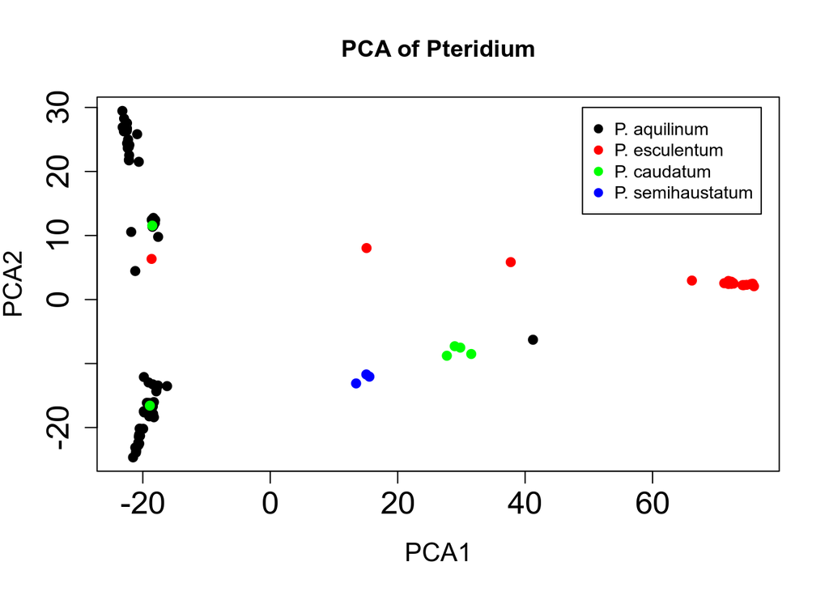

```r
# PCA
g.pca<-prcomp(g.avg, scale=TRUE)

cols <- c(rep("black", 2), "red", rep("black", 2), rep("red", 2), rep("black", 3), "red", rep("black", 10), rep("red", 2), "black", "red", rep("black",10), "red", rep("black",4), "green", "blue", "black", "green", "red", "blue", "black", "blue", rep("black", 5), rep("red", 3), "black", "green", "red", rep("black", 6), "red", "red", rep("black", 13), "red", "green", rep("black", 4), "green", "red", rep("black", 5), "red", "green", "red", "black")

# plot
plot(g.pca$x[,1], g.pca$x[,2], col = cols, xlab="PCA1",ylab="PCA2", cex.lab=1.3, cex.axis=1.6, main = "PCA of Pteridium", pch=19)
legend(49, 30, legend=c("P. aquilinum", "P. esculentum", "P. caudatum", "P. semihaustatum"), col=c("black", "red", "green", "blue"), pch=19, cex=0.9)
```

## Program Versions

Below is a list of all program versions used in this analysis. Please note that newer versions of these software packages *may* work for this pipeline, but be aware that usage often changes with new verions.

[Perl 5](https://www.perl.org/)

[Python 2.7.13](https://www.python.org/downloads/release/python-2713/)

[SAMtools v. 1.5](https://sourceforge.net/projects/samtools/files/samtools/1.5/)

[SEQTK 1.2-r102-dirty](https://github.com/lh3/seqtk)

[VSEARCH 2.4.2](https://github.com/torognes/vsearch)

[BWA 0.7.15](https://sourceforge.net/projects/bio-bwa/files/)

[PicardTools 2.9.0](https://github.com/broadinstitute/picard/releases)

[GATK v.3.8.0](https://software.broadinstitute.org/gatk/download/archive) - [HaplotypeCaller](https://software.broadinstitute.org/gatk/documentation/tooldocs/3.8-0/org_broadinstitute_gatk_tools_walkers_haplotypecaller_HaplotypeCaller.php)

[ENTROPY & ESTPOST](https://github.com/sylviakinosian/Pteridium_GBS_Pipeline/tree/master/entropy)